# LinkSimulation

```python
from IPython.core.display import HTML

def css_styling():
    styles = open("../styles/custom.css", "r").read()
    return HTML(styles)
css_styling()
```

```python
from pylayers.simul.link import *
%matplotlib inline
```

```
WARNING:traits.has_traits:DEPRECATED: traits.has_traits.wrapped_class, 'the 'implements' class advisor has been deprecated. Use the 'provides' class decorator.
```

This notebook illustrates the [`link`](http://pylayers.github.io/pylayers/modules/pylayers.simul.link.html) module. A `Dlink` is a deterministic (Single Input Single Output) SISO link.

```python
L=DLink()
```

The `repr` function provides information about the default link, which is stored in the `hdf5` file. It should correspond to the default Layout. A link gathers various objects and information e.g + Layout file + Node a (first termination of the link) + position + antenna file + antenna rotation matrix + Node b (second termination of the link) + position + antenna file + antenna rotation matrix + Frequency range + fmin + fmax + fstep

```python
L
```

```
filename: Links_0_defstr.ini.h5
Link Parameters :
------- --------
Layout : defstr.ini

Node a
------
position : [  766.00300113  1113.94747911     1.2       ]
Antenna : S2R2.sh3
Rotation matrice :
 [[ 1.  0.  0.]
 [ 0.  1.  0.]
 [ 0.  0.  1.]]

Node b
------
position : [  766.00300113  1113.94747911     1.2       ]
Antenna : S2R2.sh3
Rotation matrice :
 [[ 1.  0.  0.]
 [ 0.  1.  0.]
 [ 0.  0.  1.]]

Link evaluation information :
-----------------------------
distance :  0.000 m
delay :  0.000 ns
fmin (fGHz) : 2.0
fmax (fGHz) : 11.0
fstep (fGHz) : 0.05
```

To evaluate a link there is the `eval` method

```python
aktk=L.eval(force=[], output=['sig','ray','Ct','H'],
            si_algo='old',ra_ceil_height_meter=3,ra_number_mirror_cf=1)
```

```
Signatures'> from 1_1_3 loaded
Rays'> from 3_0_0 loaded
Ctilde'> from 0_0_0 loaded
Tchannel'> from 0_0_0_0_0_0_0 loaded
```

The propagation channel (without antenna) can be vizualized on a ray by ray mode.

```python
#L._show3()
```

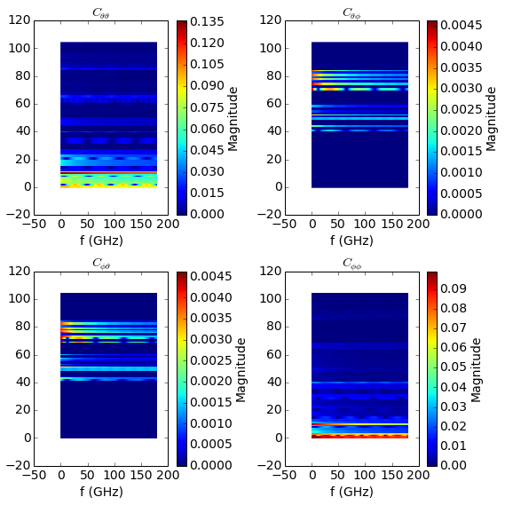

```python
fig = plt.figure(figsize=(8,8))
C = L.C
f,a = C.show(cmap='jet',fig=fig)
```

It is possible to look at individual ray transfer function, as illustrated below.

```python
C.Ctt.y.shape
```

```
(105, 181)
```

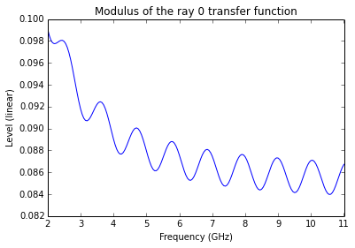

```python
ir = 0
plt.plot(C.Ctt.x,abs(C.Ctt.y[ir,:]))
plt.xlabel('Frequency (GHz)')
plt.ylabel('Level (linear)')
plt.title('Modulus of the ray '+str(ir)+' transfer function')
```

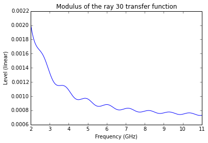

```python
ir = 30
plt.plot(C.Ctt.x,abs(C.Ctt.y[ir,:]))
plt.xlabel('Frequency (GHz)')
plt.ylabel('Level (linear)')
plt.title('Modulus of the ray '+str(ir)+' transfer function')
```

In the link we also have the transmission channel accounting for the effect of antennas and Friis factor. If the ray transfer function is scaled with $\frac{4\pi f}{c}$

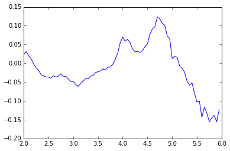

```python
plt.plot(L.H.x,L.H.y[0,:]*4*np.pi*L.H.x/0.3)
```

The infinite bandwidth channel impulse response is plotted below from the extrated set $\{\alpha_k,\tau_k\}$.

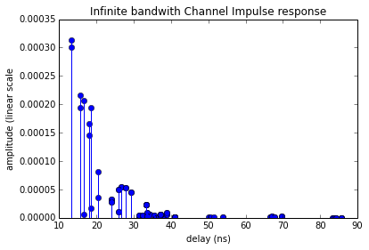

```python
plt.stem(aktk[1],aktk[0])
plt.title('Infinite bandwith Channel Impulse response')
plt.xlabel('delay (ns)')
plt.ylabel('amplitude (linear scale')
```

```python
import pylayers.simul.simulnet as sn
import pylayers.simul.simultraj as st
```

```python
S=sn.Simul()
```

```
Layout graphs are loaded from  /home/uguen/Bureau/P1 /struc/ini
```

```python
S.L
```

```
----------------
TA-Office.ini
Image('/home/uguen/Bureau/P1/struc/images/DLR4991.png')
----------------

Number of points  : 71
Number of segments  : 94
Number of sub segments  : 16
Number of cycles  : 25
Number of rooms  : 17
degree 0 : []
degree 1 : []
degree 2 : 39
degree 3 : 32

xrange :(0.0, 40.0)
yrange :(0.0, 15.0)

Useful dictionnaries
----------------
dca {cycle : []} cycle with an airwall
sl {slab name : slab dictionary}
name :  {slab :seglist}

Useful arrays
----------------
tsg : get segment index in Gs from tahe
isss :  sub-segment index above Nsmax
tgs : get segment index in tahe from Gs
lsss : list of segments with sub-segment
sla : list of all slab names (Nsmax+Nss+1)
degree : degree of nodes
```

```python
S.runsimul()
```

```python
from pylayers.mobility.trajectory import *
```

A trajectories object is a list of trajectories. The loadh5 methods by default loads the file '.h5' generated by [`Simulnet`](http://pylayers.github.io/pylayers/modules/pylayers.simul.simulnet.html).

```python
T=Trajectories()
T.loadh5()
```

```python
T
```

```
Trajectories performed in Layout : TA-Office.ini

Trajectory of agent John with ID 1
----------------------------------
t (s) : 0.00 : 0.20 : 119.80
dtot (m) : 380.33
Vmoy (m/s) : 3.17
                                    x         y        vx        vy        ax  \
t
1970-01-01 00:00:00         18.907750  2.528547  0.038749  0.155237  0.193744
1970-01-01 00:00:00.200000  18.921699  2.584433  0.069748  0.279427  0.154995

                                  ay      s
t
1970-01-01 00:00:00         0.776185  0.160
1970-01-01 00:00:00.200000  0.620948  0.448

Trajectory of agent Alex with ID 2
----------------------------------
t (s) : 0.00 : 0.20 : 119.80
dtot (m) : 232.48
Vmoy (m/s) : 1.94
                                    x         y        vx        vy        ax  \
t
1970-01-01 00:00:00         29.706510  2.528831  0.032551  0.156654  0.162753
1970-01-01 00:00:00.200000  29.718228  2.585226  0.058591  0.281977  0.130202

                                  ay      s
t
1970-01-01 00:00:00         0.783270  0.160
1970-01-01 00:00:00.200000  0.626616  0.448

Access point Router with ID 6
-----------------------------
t (s) : 0.00
Vmoy (m/s) : 0.0
              x  y    z  vx  vy  ax  ay  s
t
1970-01-01  0.5  2  2.5   0   0   0   0  0

Access point Router with ID 7
-----------------------------
t (s) : 0.00
Vmoy (m/s) : 0.0
              x   y    z  vx  vy  ax  ay  s
t
1970-01-01  0.7  14  2.5   0   0   0   0  0

Access point Router with ID 8
-----------------------------
t (s) : 0.00
Vmoy (m/s) : 0.0
             x   y    z  vx  vy  ax  ay  s
t
1970-01-01  39  13  2.5   0   0   0   0  0
```

A SimulTraj object is derived from a trajectory calculated previously in simulnet and a body agent description. The Simultraj object get the trajectories from the `simultaj.ini` file.

```python
St=st.Simul(verbose=False)
```

```
**** Processor coding ***
Intel-PC
**** Processor coding ***
Intel-PC
```

```python
#St.run(t=list(np.arange(0,1,0.1)),OB=True,B2B=True,B2I=True)
```

```python
#St.data
```

Information about the simulated network is obtained

```python
St.N
```

```
Network information
*******************
number of nodes: 7
ID      | name            |group   | type | position (x,y,z)  | wstd
---------------------------------------------------------------------------
0_Alex  | cardio          |Alex    | ag   |   nan   nan   nan | [u'bluetooth-class2']
1_John  | Galaxy Gear     |John    | ag   |   nan   nan   nan | [u'bluetooth-class2']
7       | Router          |ap      | ap   |  0.70 14.00  2.50 | [u'ieee80211b', u'ieee80211a']
6       | Router          |ap      | ap   |  0.50  2.00  2.50 | [u'ieee80211b', u'ieee80211a']
8       | Router          |ap      | ap   | 39.00 13.00  2.50 | [u'ieee80211b', u'ieee80211a']
1_Alex  | Galaxy Gear     |Alex    | ag   |   nan   nan   nan | [u'bluetooth-class2']
0_John  | cardio          |John    | ag   |   nan   nan   nan | [u'bluetooth-class2']
```

```python
#St._show3()
```

```python
#St.data.head()
```

```python
#ak,tk,ek=St._loadh5(2,'0_Alex','1_Alex','bluetooth-class2')
```

```python
#stem(tk,ak)
```